# Has the use of statistics produced a measurable result of run production in Major League Baseball, or are the latest numbers simply a normal progression of the game as time goes on? (image should be a

*Beginning of plots for alternative hypothesis, showing how OBP alone or BA alone correlate to R production*

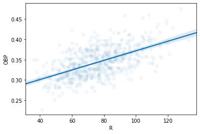

```python
sns.regplot(x='R', y='OBP', data=lmLastFive, scatter_kws={'alpha':0.05})
plt.show()
```

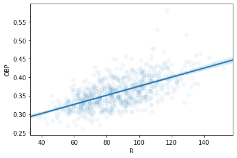

```python
sns.regplot(x='R', y='OBP', data=sdLastFive, scatter_kws={'alpha':0.05})
plt.show()
```

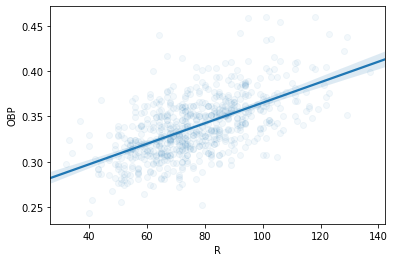

```python
sns.regplot(x='R', y='OBP', data=stLastFive, scatter_kws={'alpha':0.05})
plt.show()
```

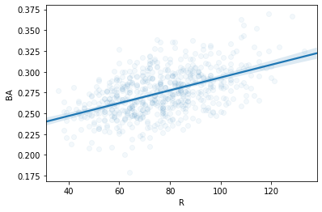

```python
sns.regplot(x='R', y='BA', data=lmLastFive, scatter_kws={'alpha':0.05})
plt.show()
```

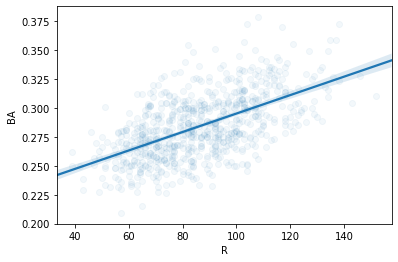

```python
sns.regplot(x='R', y='BA', data=sdLastFive, scatter_kws={'alpha':0.05})
plt.show()
```

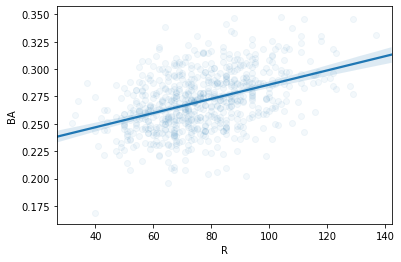

```python
sns.regplot(x='R', y='BA', data=stLastFive, scatter_kws={'alpha':0.05})
plt.show()
```

*Beginning of statistical analysis with samples to test whether distribution is regular or not*

*Ttest of eras lowerMound and stats given the presumption of a lack of PED usage, OBP and R*

```python
print(stats.ttest_ind(lowerMound['OPS'], statsEra['OPS'])) #null = reject pvalue=9.264435572999819e-08
print(stats.ttest_ind(lowerMound['R'], statsEra['R'])) #null = reject pvalue=0.028278847088743862
print(stats.ttest_ind(lowerMound['OBP'], statsEra['OBP'])) #null = rejct pvalue=0.005822886802050661
print(stats.ttest_ind(lowerMound['SLUG'], statsEra['SLUG'])) #null = reject pvalue=3.059099661607167e-18
print(stats.ttest_ind(lowerMound['BA'], statsEra['BA'])) #null = reject pvalue=0.00029315404042579276
print(stats.ttest_ind(lowerMound['PA'], statsEra['PA'])) #null = accept
print(stats.ttest_ind(lowerMound['AB'], statsEra['AB'])) #null = accept
```

```
Ttest_indResult(statistic=-5.352096706516884, pvalue=9.264435572999819e-08)
Ttest_indResult(statistic=-2.1943250154243454, pvalue=0.028278847088743862)
Ttest_indResult(statistic=2.759321148067626, pvalue=0.005822886802050661)
Ttest_indResult(statistic=-8.758230406552341, pvalue=3.059099661607167e-18)
Ttest_indResult(statistic=3.6250020193435937, pvalue=0.00029315404042579276)
Ttest_indResult(statistic=-0.4307034370593669, pvalue=0.6667110660596509)
Ttest_indResult(statistic=-0.6934771259789159, pvalue=0.48805710481748343)
```

*Ttest of "last five" years of each era to attempt to correct for simple player improvement because of the passage of time, hopefully not ostensibly.*

```python
print(stats.ttest_ind(lmLastFive['OPS'], stLastFive['OPS'])) #null = reject pvalue=0.004930227014237343
print(stats.ttest_ind(lmLastFive['R'], stLastFive['R'])) #null = accept
print(stats.ttest_ind(lmLastFive['OBP'], stLastFive['OBP'])) #null = reject pvalue=0.012989154868119981
print(stats.ttest_ind(lmLastFive['SLUG'], stLastFive['SLUG'])) #null = reject pvalue=1.6788897883125095e-07
print(stats.ttest_ind(lmLastFive['BA'], stLastFive['BA'])) #null = reject pvalue=0.007870697821893905
print(stats.ttest_ind(lmLastFive['PA'], stLastFive['PA'])) #null = accept
print(stats.ttest_ind(lmLastFive['AB'], stLastFive['AB'])) #null = accept
```

```
Ttest_indResult(statistic=-2.8164325144059137, pvalue=0.004930227014237343)
Ttest_indResult(statistic=-0.6558684942228415, pvalue=0.5120260610536571)
Ttest_indResult(statistic=2.4875337925894367, pvalue=0.012989154868119981)
Ttest_indResult(statistic=-5.260770227744551, pvalue=1.6788897883125095e-07)
Ttest_indResult(statistic=2.661738424456634, pvalue=0.007870697821893905)
Ttest_indResult(statistic=-0.6205259636066971, pvalue=0.5350215153592877)
Ttest_indResult(statistic=-1.2384561204859503, pvalue=0.21577300021623674)
```

*And that is very interesting. Everything fell along the same lines, though with reduced distance, until R, which flipped from a reject to an accept, when comparing the last five years of players in lowerMound, 1987-1991, to the last five years of players in the stats generation, 2014-18.*

*Granted, this could be due to the elevated use of PEDs about to seize control of MLB, but at this point I do not know how to test for that.*